# Titanic Solution

www.PredictiveInsightsAI.com Practice Exam

10 June, 2020

For your convenience, this solution document has been formatted to be easy to read. When taking this exam, candidates are not expected to make their `.Rmd` documents look this way. The `make_table` function is included only to improve your reading experience. The SOA’s instructions from the Project Statement say only that

> At a minimum you must submit your completed report template and an Rmd file that supports your work. Graders expect that your Rmd code can be run from beginning to end. The code snippets provided should either be commented out or adapted for execution. Ensure that it is clear where in the code each of the tasks is addressed. Documentation of your thought process and conclusion for each task should be completely contained within your Word report. The Rmd code should be clear, may contain commentary, and support your work.

Your assistant has provided code throughout this document. The structure of the code can always be treated as being correct, however, there is no gaurantee that the parameter choices are best.

```r
#NO CHANGES NEEDED
set.seed(1234)
#install.packages(c("car", "fastDummies", "ROCR"))
library(caret)
library(randomForest)
library(rpart)
library(rpart.plot)
library(car)
library(e1071)
library(broom)
library(fastDummies)
library(caret)
library(ROCR)
library(tidyverse)
library(glmnet)
library(dplyr)
library(scales)
library(kableExtra)
library(ExamPAData)
theme_set(theme_minimal())

#function to create html tables
make_table <- function(df, caption = ""){
  df %>%
    kable(caption = caption) %>%
    kable_styling(bootstrap_options = "striped", full_width = F)}

#global chunk options
knitr::opts_chunk$set(warning = F, message = F, echo = T, fig.width = 14, fig.height = 8, dev.args = list(type = "cairo"))
```

```r
#NO CHANGES NEEDED
#This code was used to add 15 "fake" outliers
#This is being included so that you can see how it was created

df <- read_csv("train.csv")
names(df) <- tolower(names(df))
#impute median or mode values
df <- df %>% mutate(age = ifelse(is.na(age), median(df$age, na.rm = T), age),
                    embarked = ifelse(is.na(embarked), "S", embarked)) %>%
  select(-cabin)

#add 15 outlier points
#outliers should be for age, fare,  pclass, family_size
n_outliers <- 15
outliers <- tibble(
  passengerid = 1:n_outliers,
  survived = sample(c(1,0), n_outliers, replace = T),
  pclass = sample(3, n_outliers, replace = T),
  name = sample(df$name, n_outliers, replace = T),
  sex = sample(df$sex, n_outliers, replace = T),
  age = sample(c(1, 100, 105, 97, 0), n_outliers, replace = T),
  sibsp = sample(c(5,10, 20),n_outliers, replace = T),
  parch = sample(df$parch, n_outliers, replace = T) + 5,
  ticket = sample(df$ticket, n_outliers, replace = T),
  fare = runif(n_outliers, min = 600, max = 1200),
  embarked = sample(df$embarked, n_outliers, replace = T)
)

df <- df %>% mutate(fare = ifelse(fare == 0, median(df$fare), fare))
df <- df %>% rbind(outliers)
df %>% write_csv("titanic.csv")
```

```r
#NO CHANGES NEEDED
#convert factor levels to those with the most observations
df <- exam_pa_titanic %>%
  mutate_at(.vars = c("sex", "embarked"), .funs = fct_infreq)
```

## Task 1 - Explore the survival rates by sex, pclass, and embarked. Apply a transform to fare if necessary.

```r
df %>% glimpse()
```

```
## Observations: 906
## Variables: 11
## $ passengerid <dbl> 1, 2, 3, 4, 5, 6, 7, 8, 9, 10, 11, 12, 13, 14, 15, 16, ...
## $ survived    <dbl> 0, 1, 1, 1, 0, 0, 0, 0, 1, 1, 1, 1, 0, 0, 0, 1, 0, 1, 0...
## $ pclass      <dbl> 3, 1, 3, 1, 3, 3, 1, 3, 3, 2, 3, 1, 3, 3, 3, 2, 3, 2, 3...
## $ name        <chr> "Braund, Mr. Owen Harris", "Cumings, Mrs. John Bradley ...
## $ sex         <fct> male, female, female, female, male, male, male, male, f...
## $ age         <dbl> 22, 38, 26, 35, 35, 28, 54, 2, 27, 14, 4, 58, 20, 39, 1...
## $ sibsp       <dbl> 1, 1, 0, 1, 0, 0, 0, 3, 0, 1, 1, 0, 0, 1, 0, 0, 4, 0, 1...
## $ parch       <dbl> 0, 0, 0, 0, 0, 0, 0, 1, 2, 0, 1, 0, 0, 5, 0, 0, 1, 0, 0...
## $ ticket      <chr> "A/5 21171", "PC 17599", "STON/O2. 3101282", "113803", ...
## $ fare        <dbl> 7.2500, 71.2833, 7.9250, 53.1000, 8.0500, 8.4583, 51.86...
## $ embarked    <fct> S, C, S, S, S, Q, S, S, S, C, S, S, S, S, S, S, Q, S, S...
```

```r
#can also use
#summary(df)
#str(df)
```

```r
#NO CHANGES NEEDED
df %>% count(survived) %>% mutate(percent_of_passengers = percent(n/sum(n))) %>% make_table()
```

| survived | n | percent_of_passengers |
| --- | --- | --- |
| 0 | 552 | 61% |
| 1 | 354 | 39% |

```r
#NO CHANGES NEEDED
df %>%
  group_by(sex) %>%
  summarise(n = n(),
          percent_survived = percent(sum(survived==1)/n()))%>% make_table()
```

| sex | n | percent_survived |
| --- | --- | --- |
| male | 590 | 20% |
| female | 316 | 74% |

```r
df %>%
  group_by(pclass) %>%
  summarise(n = n(),
            percent_survived = percent(sum(survived==1)/n()))%>% make_table()
```

| pclass | n | percent_survived |
| --- | --- | --- |
| 1 | 225 | 64% |
| 2 | 187 | 48% |
| 3 | 494 | 24% |

```r
df %>%
  group_by(embarked) %>%
  summarise(n = n(),
           percent_survived = percent(sum(survived==1)/n()))%>% make_table()
```

| embarked | n | percent_survived |
| --- | --- | --- |
| S | 655 | 35% |
| C | 173 | 56% |
| Q | 78 | 40% |

```r
summary(df$fare)
```

```
##     Min.  1st Qu.   Median     Mean  3rd Qu.     Max.
##    4.013    8.034   14.500   46.151   31.387 1146.068
```

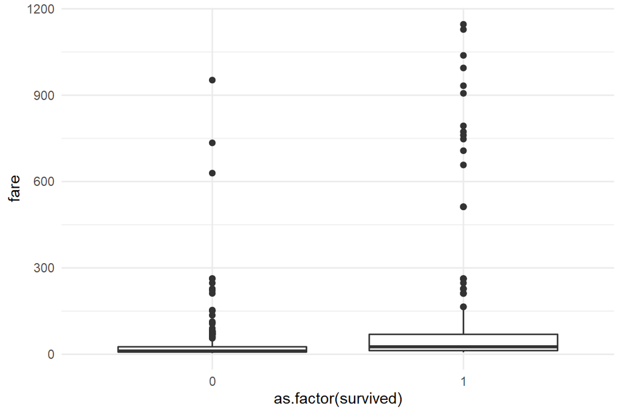

```r
df %>%
  ggplot(aes(as.factor(survived), fare)) +
  geom_boxplot()
```

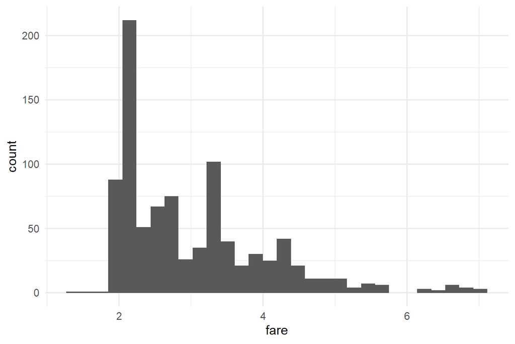

```r
df <- df %>% mutate(fare = log(fare))
df %>% ggplot(aes(fare)) + geom_histogram()
```

```r
summary(df$age)
```

```
##    Min. 1st Qu.  Median    Mean 3rd Qu.    Max.
##    0.00   22.00   28.00   29.88   35.00  105.00
```

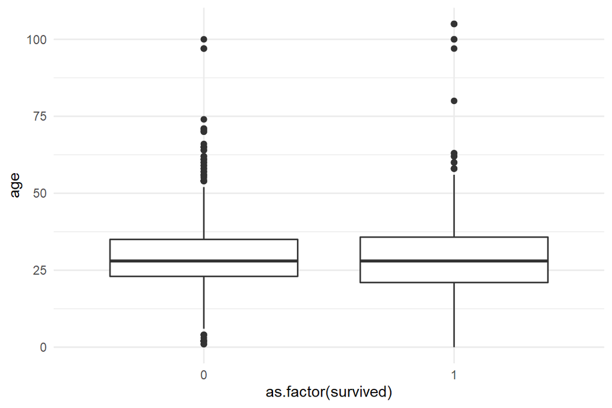

```r
df %>%
  ggplot(aes(as.factor(survived), age)) +
  geom_boxplot()
```

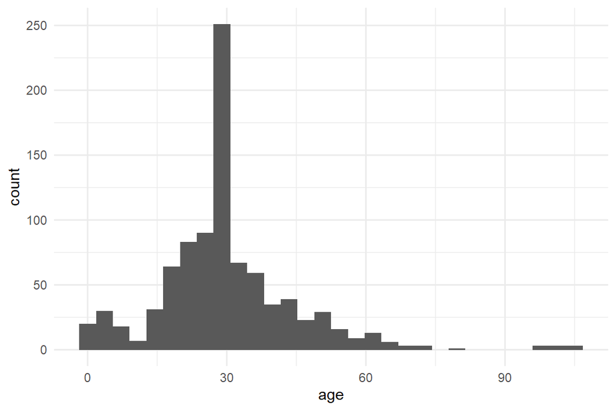

```r
df %>% ggplot(aes(age)) + geom_histogram()
```

## Task 2 - Create a new variable called “title”

```r
##Lets extract the title and check if we have predictive power in that
df <- df %>% mutate(title = gsub("^.*, (.*?)\\..*$", "\\1", name))

df %>% count(title)
```

```
## # A tibble: 17 x 2
##    title            n
##    <chr>        <int>
##  1 Capt             1
##  2 Col              2
##  3 Don              1
##  4 Dr               7
##  5 Jonkheer         2
##  6 Lady             1
##  7 Major            2
##  8 Master          41
##  9 Miss           184
## 10 Mlle             2
## 11 Mme              1
## 12 Mr             523
## 13 Mrs            130
## 14 Ms               1
## 15 Rev              6
## 16 Sir              1
## 17 the Countess     1
```

```r
df <- df %>% mutate(
  title = case_when(
    title %in% c("Miss","Mlle","Ms", "MS", "Lady", "Dona") ~ "Miss",
    title == "Mme" ~ "Mrs",
    title %in% c("Officer", "Capt", "Col", "Major", "Dr", "Rev", "Don", "Sir", "the Countess", "Jonkheer") ~ "Officer",
    T ~ title
  ) %>% fct_infreq()
)
df %>% count(title) %>% make_table()
```

| title | n |
| --- | --- |
| Mr | 523 |
| Miss | 188 |
| Mrs | 131 |
| Master | 41 |
| Officer | 23 |

```r
#BASE R TEMPLATE
##Lets extract the title and check if we have predictive power in that
df$title <- gsub("^.*, (.*?)\\..*$", "\\1", df$name)

table(df$title)
```

```
##
##         Capt          Col          Don           Dr     Jonkheer         Lady
##            1            2            1            7            2            1
##        Major       Master         Miss         Mlle          Mme           Mr
##            2           41          184            2            1          523
##          Mrs           Ms          Rev          Sir the Countess
##          130            1            6            1            1
```

```r
#This code simplies the title
#For example, passengers which have "Miss", "Mlle", "MS", or "Ms" in their name get the title "Miss"
df$title <- ifelse(df$title %in% c("Miss","Mlle","Ms", "MS", "Lady", "Dona"), yes = "Miss", no = df$title)
df$title <- ifelse(df$title == "Mme", yes = "Mrs", no = df$title)
df$title <- ifelse(df$title %in% c("Officer", "Capt", "Col", "Major", "Dr", "Rev", "Don", "Sir", "the Countess", "Jonkheer"), yes = "Officer", no = df$title)

table(df$title)
```

```
##
##  Master    Miss      Mr     Mrs Officer
##      41     188     523     131      23
```

```r
#Set the base factor level to the title with the most observations
df$title <- fct_infreq(df$title)
```

## Task 3 - Create a new variable called “family_size”

```r
df <- df %>% mutate(family_size = sibsp + parch + 1)

#df$famil_size = df$sibsp + df$parch + 1
```

## Task 4 - Use kmeans to detect outliers

```r
#NO CHANGES NEEDED
set.seed(1234)
cluster_data <- df %>%
  select(age, fare,  pclass, family_size) %>%
  mutate(fare = exp(fare))#undo the log transform for clustering

run_kmeans <- function(centers, nstart){
  kmeans = kmeans(cluster_data, centers = centers, nstart = nstart)

  df <- cluster_data %>% mutate(
    cluster = as.factor(kmeans$cluster)
  )

  counts <- df %>% count(cluster)
  list("kmeans" = kmeans, "counts" = counts)
}
```

```r
#Run KMeans
#Choose values for centers and nstart
run1 <- run_kmeans(centers = 10, nstart = 3)
run1$counts
```

```
## # A tibble: 10 x 2
##    cluster     n
##    <fct>   <int>
##  1 1          33
##  2 2         103
##  3 3          54
##  4 4          61
##  5 5         115
##  6 6          69
##  7 7         291
##  8 8          15
##  9 9          20
## 10 10        145
```

```r
run2 <- run_kmeans(centers = 2,nstart = 50)
run2$counts %>% make_table()
```

| cluster | n |
| --- | --- |
| 1 | 18 |
| 2 | 888 |

```r
run3 <- run_kmeans(centers = 3,nstart = 50)
run3$counts %>% make_table()
```

| cluster | n |
| --- | --- |
| 1 | 101 |
| 2 | 787 |
| 3 | 18 |

```r
#select the kmeans run to use
#select the clusters which you are counting as outliers
#i.e., if clusters 4 and 5 were the "outliers", say outlier_clusters <- c(4,5)

selected_run <- run3
outlier_clusters <- c(3)

#add selected cluster assignment to the data
df <- df %>% mutate(
  cluster = selected_run$kmeans$cluster %>% as.factor(),
  outlier_flag = ifelse(cluster %in% outlier_clusters, 1, 0) %>% as.factor() %>% fct_infreq()
)
```

## Cluster Assignments

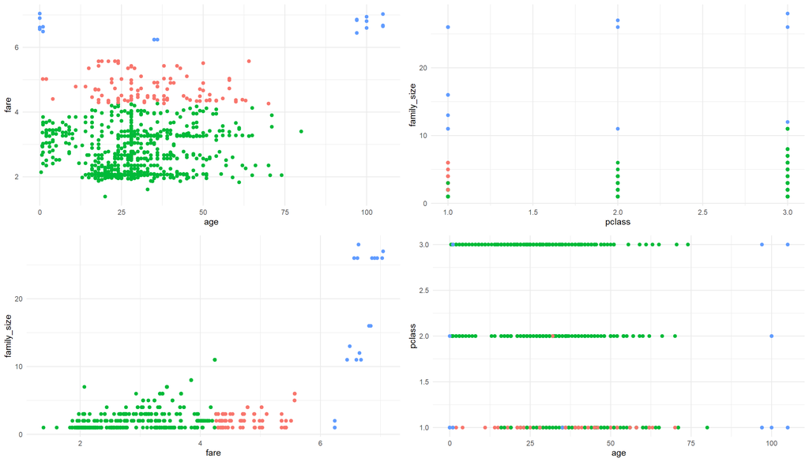

```r
#NO CHANGES NEEDED
p1 <- df %>% ggplot(aes(age,fare, color = cluster)) + geom_point() + theme(legend.position = "none")
p2 <- df %>% ggplot(aes(pclass,family_size, color = cluster)) + geom_point()+ theme(legend.position = "none")
p3 <- df %>% ggplot(aes(fare,family_size, color = cluster)) + geom_point()+ theme(legend.position = "none")
p4 <- df %>% ggplot(aes(age,pclass, color = cluster)) + geom_point()+ theme(legend.position = "none")
gridExtra::grid.arrange(p1,p2,p3, p4)
```

```r
df <- df %>% select(-cluster)
```

## Probable Outliers

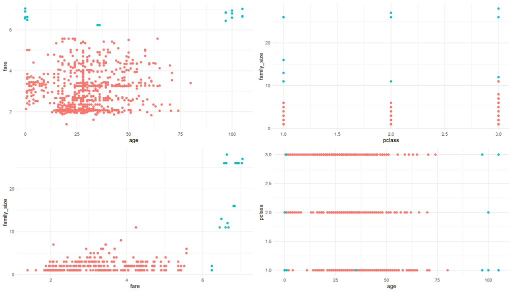

```r
#NO CHANGES NEEDED
p1 <- df %>% ggplot(aes(age,fare, color = outlier_flag)) + geom_point() + theme(legend.position = "none")
p2 <- df %>% ggplot(aes(pclass,family_size, color = outlier_flag)) + geom_point()+ theme(legend.position = "none")
p3 <- df %>% ggplot(aes(fare,family_size, color = outlier_flag)) + geom_point()+ theme(legend.position = "none")
p4 <- df %>% ggplot(aes(age,pclass, color = outlier_flag)) + geom_point()+ theme(legend.position = "none")
gridExtra::grid.arrange(p1,p2,p3, p4)
```

## Task 5 - Select which variables should be used in modeling

```r
#SELECT WHICH VARIABLES YOU WANT TO REMOVE
variables_to_remove <- c("passengerid", "name", "ticket")
df <- df %>% select(-variables_to_remove)
```

```r
#NO CHANGES NEEDED
#create dummy columns and split into train and test sets
df_factors <- df %>% select(pclass, sex, embarked, title)
df_dummies = df %>%
  dummy_cols(remove_first_dummy = T) %>%
  select(-sex, -title, -embarked)

df_dummies %>% dim()
```

```
## [1] 906  16
```

```r
df <- df_dummies

train_index <- createDataPartition(df$survived, p = 0.75, list = F) %>% as.numeric()
train <- df %>% dplyr::slice(train_index)
test <- df %>% dplyr::slice(-train_index)
train %>% summarise(train_percent_survived = sum(survived==1)/n())
```

```
## # A tibble: 1 x 1
##   train_percent_survived
##                    <dbl>
## 1                  0.396
```

```r
test %>% summarise(test_percent_survived = sum(survived==1)/n())
```

```
## # A tibble: 1 x 1
##   test_percent_survived
##                   <dbl>
## 1                 0.376
```

```r
dim(train)
```

```
## [1] 680  16
```

## Task 6 - Fit a random forest for variable selection

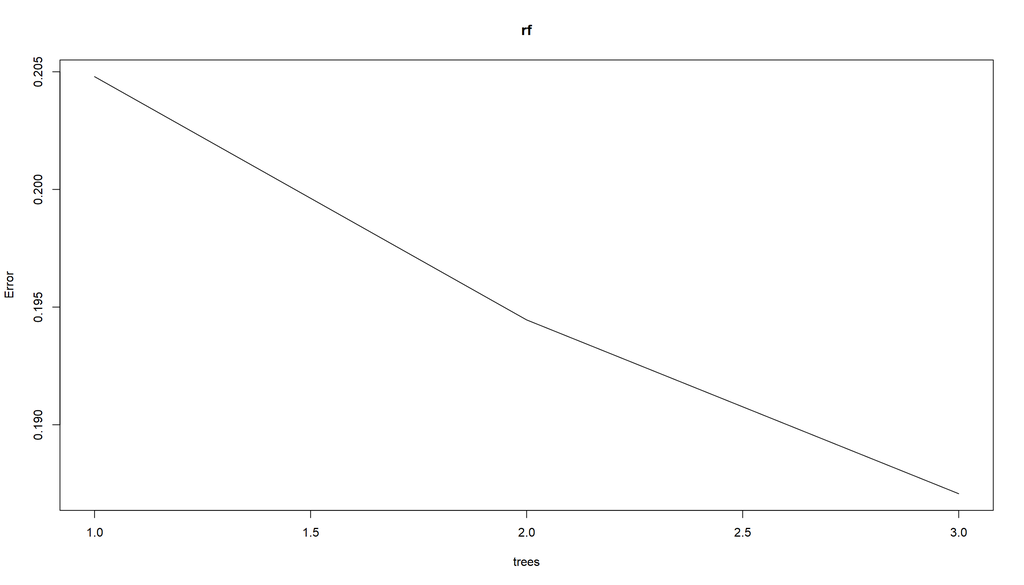

```r
set.seed(1234)
#remove cabin, ticket, name
rf <- randomForest(survived~.,
                     data = train,
                     ntree = 3, #MAKE A SELECTION
                     mtry = 300,#MAKE A SELECTION
                  importance = T)

plot(rf)
```

```r
predictions <- as.vector(predict(rf, test))
pred <- prediction(predictions, test$survived)

accuracy <- sum((predict(rf, test) > 0.5) == test$survived)/nrow(test)

perf_measures <- performance(pred, "auc")
auc <- perf_measures@y.values[[1]]

print("Accuracy")
```

```
## [1] "Accuracy"
```

```r
accuracy
```

```
## [1] 0.7699115
```

```r
print("AUC")
```

```
## [1] "AUC"
```

```r
auc
```

```
## [1] 0.7966208
```

```r
#VARIABLE IMPORTANCE
importance <- varImp(rf)
rf_results <- tibble(variable = rownames(importance),
       importance = importance$Overall) %>%
  arrange(desc(importance)) %>%
  head(7)

rf_results %>% make_table()
```

| variable | importance |
| --- | --- |
| sex_female | 11.091018 |
| fare | 7.133032 |
| age | 5.965294 |
| title_Master | 4.327094 |
| pclass | 3.367949 |
| embarked_Q | 2.218478 |
| sibsp | 2.072890 |

```r
#note: ignore the error "The response has five or fewer unique values.  Are you sure you want to do regression?".  This is due to a bug in the randomForest library.
```

```r
sqrt(ncol(train))
```

```
## [1] 4
```

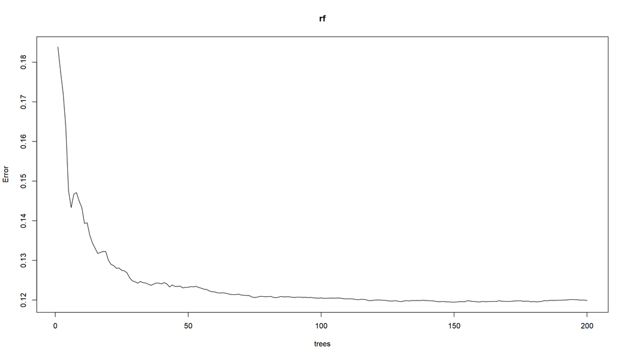

```r
set.seed(1234)
rf <- randomForest(survived~.,
                     data = train,
                     ntree = 200,
                     mtry = 4, #the default value
                  importance = T,
                  keep.forest = T)
plot(rf)
```

```r
predictions <- as.vector(predict(rf, newdata =test))
pred <- prediction(predictions, test$survived)

accuracy <- sum((predict(rf, test) > 0.5) == test$survived)/nrow(test)

perf_measures <- performance(pred, "auc")
auc <- perf_measures@y.values[[1]]

print("Accuracy")
```

```
## [1] "Accuracy"
```

```r
accuracy
```

```
## [1] 0.8097345
```

```r
print("AUC")
```

```
## [1] "AUC"
```

```r
auc
```

```
## [1] 0.8329579
```

## Task 7 - Choose the top 7 variables by importance

```r
#NO CHANGES NEEDED
importance <- varImp(rf)
rf_results <- tibble(variable = rownames(importance),
       importance = importance$Overall) %>%
  arrange(desc(importance)) %>%
  head(7)

rf_results %>% make_table()
```

| variable | importance |
| --- | --- |
| sex_female | 25.07011 |
| pclass | 24.77674 |
| fare | 20.39066 |
| age | 15.70338 |
| family_size | 15.40967 |
| title_Master | 13.24262 |
| title_Miss | 12.42643 |

## Task 8 - Fit a logistic regression and interpret the coefficients

```r
#SELECT VARIABLES TO USE IN LOGIT
#Note: parch, sibsib, or family size are linearly dependent
logit_vars <- c("survived", "sex_female", "pclass", "age", "fare", "title_Master", "family_size", "title_Miss")
```

```r
#NO CHANGES NEEDED
logit_train <- train %>% select(logit_vars)
logit_test <- test %>% select(logit_vars)

model <- glm(survived ~ .,
            family = binomial(link="logit"),
            data = logit_train)
summary(model)
```

```
##
## Call:
## glm(formula = survived ~ ., family = binomial(link = "logit"),
##     data = logit_train)
##
## Deviance Residuals:
##     Min       1Q   Median       3Q      Max
## -2.4923  -0.6356  -0.3639   0.6122   2.3718
##
## Coefficients:
##               Estimate Std. Error z value Pr(>|z|)
## (Intercept)   0.479061   0.995246   0.481    0.630
## sex_female    3.087537   0.319367   9.668  < 2e-16 ***
## pclass       -1.108434   0.216842  -5.112 3.19e-07 ***
## age          -0.004399   0.007627  -0.577    0.564
## fare          0.138923   0.212204   0.655    0.513
## title_Master  2.403651   0.472665   5.085 3.67e-07 ***
## family_size   0.003570   0.049765   0.072    0.943
## title_Miss   -0.155543   0.343750  -0.452    0.651
## ---
## Signif. codes:  0 '***' 0.001 '**' 0.01 '*' 0.05 '.' 0.1 ' ' 1
##
## (Dispersion parameter for binomial family taken to be 1)
##
##     Null deviance: 912.81  on 679  degrees of freedom
## Residual deviance: 591.49  on 672  degrees of freedom
## AIC: 607.49
##
## Number of Fisher Scoring iterations: 5
```

```r
model %>% tidy() %>% select(term, estimate) %>% make_table()
```

| term | estimate |
| --- | --- |
| (Intercept) | 0.4790611 |
| sex_female | 3.0875369 |
| pclass | -1.1084342 |
| age | -0.0043989 |
| fare | 0.1389233 |
| title_Master | 2.4036509 |
| family_size | 0.0035698 |
| title_Miss | -0.1555431 |

## Task 9 - Using the model’s coefficients, calculate the probability for persons of age 10, 30, and 60 of surviving

```r
#NO CHANGES NEEDED
#This code gets the median (for continuous) and mode (for categorical) variables
continuous_vars <- c("fare", "family_size", "family_size")
train %>% select(continuous_vars) %>% summarise_all(~round(median(.x),1))
```

```
## # A tibble: 1 x 2
##    fare family_size
##   <dbl>       <dbl>
## 1   2.7           1
```

```r
categorical_vars <- c("sex_female", "pclass","title_Master", "title_Miss")
getmode <- function(v) {
   uniqv <- unique(v)
   uniqv[which.max(tabulate(match(v, uniqv)))]
}
train %>% select(categorical_vars) %>% summarise_all(getmode)
```

```
## # A tibble: 1 x 4
##   sex_female pclass title_Master title_Miss
##        <int>  <dbl>        <int>      <int>
## 1          0      3            0          0
```

```r
#check that the Excel calculation matches
#create a fake passenger with age 10
person_age_10 <- tibble(age = 10, #should be set to the median age
                        fare = 2.7, #should be set to the median fare
                        family_size = 1, #should be set to the median family size
                        title_Miss = 0, #should be set to the mode of title_Mrs
                        pclass = 3, #etc
                        sex_female = 0,
                        title_Master = 0)
```

```r
#NO CHANGES NEEDED
#CHECK THAT THE EXCEL CALCULATION MATCHES
predict(model, person_age_10, type = "response")
```

```
##         1
## 0.0750512
```

```r
person_age_30 = person_age_10 %>% mutate(age = 30)
predict(model, person_age_30, type = "response")
```

```
##          1
## 0.06916765
```

```r
person_age_60 = person_age_10 %>% mutate(age = 60)
predict(model, person_age_60, type = "response")
```

```
##          1
## 0.06113926
```

## Task 10 - Validate the logistic regression

```r
#NO CHANGES NEEDED
predictions <- as.vector(predict(model, test))
pred <- prediction(predictions, test$survived)
perf_measures <- performance(pred, "auc")
auc <- perf_measures@y.values[[1]]

print("Accuracy")
```

```
## [1] "Accuracy"
```

```r
sum((predict(model, test) > 0.5) == test$survived)/nrow(test)
```

```
## [1] 0.800885
```

```r
print("AUC")
```

```
## [1] "AUC"
```

```r
auc
```

```
## [1] 0.8302461
```

## Task 11 - Fit an elastic net

```r
x <- model.matrix(survived ~ .^2, data = logit_train )
colnames(x)
```

```
##  [1] "(Intercept)"              "sex_female"
##  [3] "pclass"                   "age"
##  [5] "fare"                     "title_Master"
##  [7] "family_size"              "title_Miss"
##  [9] "sex_female:pclass"        "sex_female:age"
## [11] "sex_female:fare"          "sex_female:title_Master"
## [13] "sex_female:family_size"   "sex_female:title_Miss"
## [15] "pclass:age"               "pclass:fare"
## [17] "pclass:title_Master"      "pclass:family_size"
## [19] "pclass:title_Miss"        "age:fare"
## [21] "age:title_Master"         "age:family_size"
## [23] "age:title_Miss"           "fare:title_Master"
## [25] "fare:family_size"         "fare:title_Miss"
## [27] "title_Master:family_size" "title_Master:title_Miss"
## [29] "family_size:title_Miss"
```

```r
lasso_cv <- cv.glmnet(x = x,
            y = train$survived,
            family = "binomial",
            alpha = 1) #alpha = 1 implies LASSO, alpha = 0 implies ridge
```

## Task 12 - Choose a value of lambda

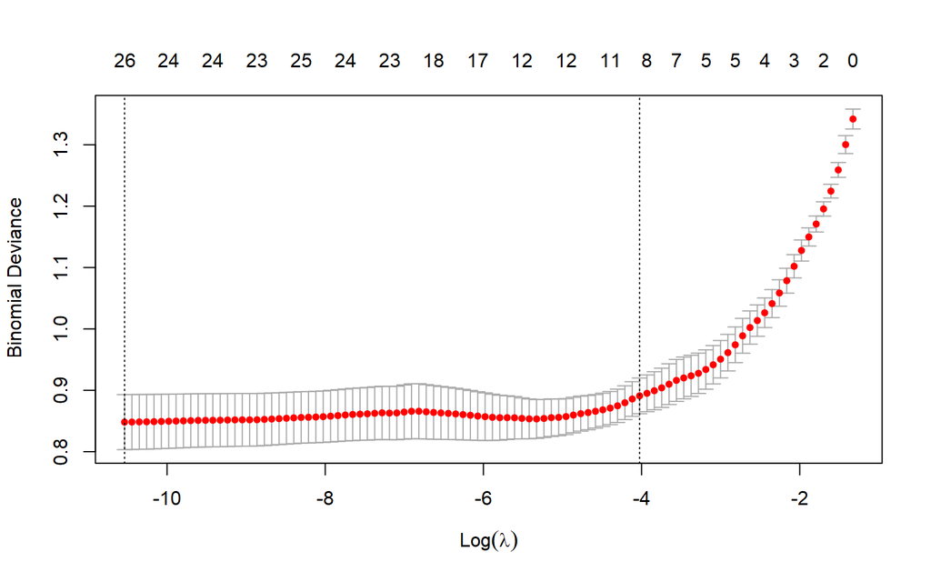

```r
plot(lasso_cv)
```

```r
log(lasso_cv$lambda.min)
```

```
## [1] -10.5372
```

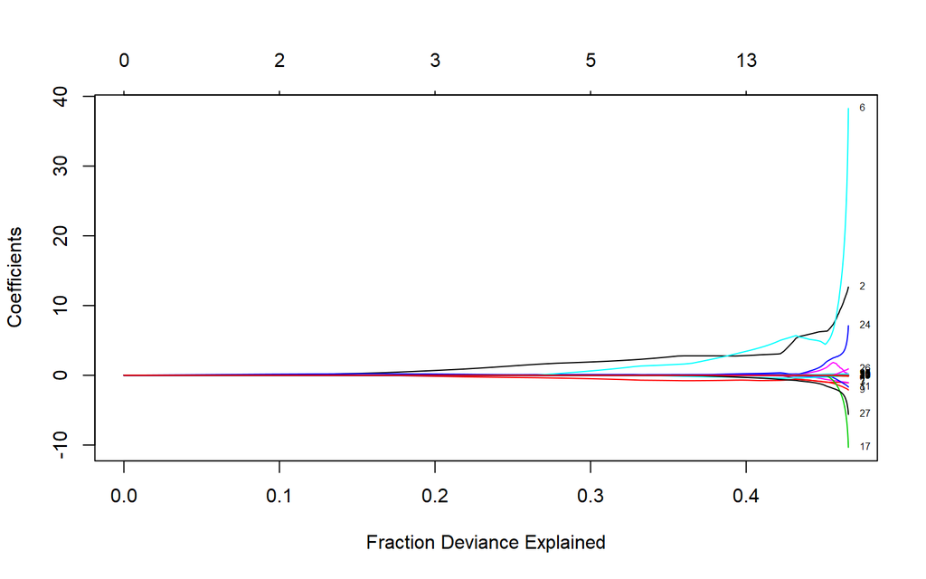

```r
model <- glmnet(x = x,
            y = logit_train$survived,
            family = "binomial",
            alpha = 1) #alpha = 1 implies LASSO, alpha = 0 implies ridge

plot(model, label = T, xvar = "dev")
```

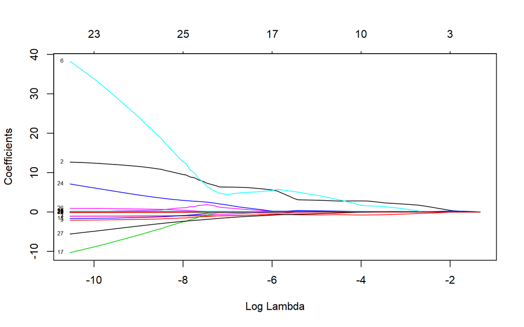

```r
model <- glmnet(x = x,
            y = logit_train$survived,
            family = "binomial",
            alpha = 1) #alpha = 1 implies LASSO, alpha = 0 implies ridge

plot(model, label = T, xvar = "lambda")
```

```r
selected_lambda <- lasso_cv$lambda.min
selected_lambda <- exp(-4)

model <- glmnet(x = x,
            y = logit_train$survived,
            family = "binomial",
            lambda = selected_lambda,
            alpha = 1)

model$beta
```

```
## 29 x 1 sparse Matrix of class "dgCMatrix"
##                                    s0
## (Intercept)               .
## sex_female                2.783103059
## pclass                   -0.778888639
## age                       .
## fare                      0.091777363
## title_Master              1.656034760
## family_size               .
## title_Miss                .
## sex_female:pclass         .
## sex_female:age            .
## sex_female:fare           0.054991592
## sex_female:title_Master   .
## sex_female:family_size   -0.176344132
## sex_female:title_Miss     .
## pclass:age               -0.001388032
## pclass:fare               .
## pclass:title_Master       .
## pclass:family_size       -0.001456403
## pclass:title_Miss         .
## age:fare                  .
## age:title_Master          .
## age:family_size           .
## age:title_Miss            .
## fare:title_Master         .
## fare:family_size          0.006868051
## fare:title_Miss           .
## title_Master:family_size  .
## title_Master:title_Miss   .
## family_size:title_Miss    .
```

## Task 13 - Compare the AUC with the logit’s AUC

```r
#NO CHANGES NEEDED
x_test <- model.matrix(survived ~ .^2, data = logit_test)

predictions <- as.vector(predict(model, x_test))
pred <- prediction(predictions, test$survived)
perf_measures <- performance(pred, "auc")
auc <- perf_measures@y.values[[1]]

print("Accuracy")
```

```
## [1] "Accuracy"
```

```r
sum((predictions > 0.1) == test$survived)/nrow(test)
```

```
## [1] 0.8097345
```

```r
print("AUC")
```

```
## [1] "AUC"
```

```r
auc
```

```
## [1] 0.8375887
```